# Lab week 2 - Stacking

Data Science and Machine Learning 3 - CEU 2019

Jeno Pal

2019-02-25

```r
library(GGally)
library(GGally)
library(h2o)
h2o.init()
```

[output not shown]

Stacking:

- specify different $L$ predictive models
- score training observations using out-of-fold predictions
- this gives a “level-one” data: the original outcome and the scores coming from the $L$ base models
- use these to estimate a second level predictive model (“meta-learner”)

When predicting new observations

- the base models are estimated using all training observations, use these to get scores for the new observation
- input this to the meta-learner model to get the predicted outcome

The more uncorrelated predictions are, the more room there is to improve individual models.

Stacked models do not always perform better than individual ones but many times they do.

It is very convenient to create stacked ensembles in h2o, we are gaining practice with this now. See more [here](http://docs.h2o.ai/h2o/latest-stable/h2o-docs/data-science/stacked-ensembles.html).

```r
data <- h2o.importFile("../../data/airlines/airline100K.csv")
data <- h2o.importFile("../../data/airlines/airline100K.csv")
data_split <- h2o.splitFrame(data, ratios = 0.2, seed = 123)
data_train <- data_split[[1]]
data_test <- data_split[[2]]
y <- "dep_delayed_15min"
X <- setdiff(names(data_train), y)
```

Train some base learners using cross validation.

```r
glm_model <- h2o.glm(
  X, y,
  training_frame = data_train,
  family = "binomial",
  alpha = 1,
  lambda_search = TRUE,
  seed = 123,
  nfolds = 5,
  keep_cross_validation_predictions = TRUE  # this is necessary to perform later stacking
)
```

```r
gbm_model <- h2o.gbm(
  X, y,
  training_frame = data_train,
  ntrees = 200,
  max_depth = 10,
  learn_rate = 0.1,
  seed = 123,
  nfolds = 5,
  keep_cross_validation_predictions = TRUE
)
```

```r
deeplearning_model <- h2o.deeplearning(
  X, y,
  training_frame = data_train,
  hidden = c(32, 8),
  seed = 123,
  nfolds = 5,
  keep_cross_validation_predictions = TRUE
)
```

```r
ensemble_model <- h2o.stackedEnsemble(
  X, y,
  training_frame = data_train,
  base_models = list(glm_model,
                     gbm_model,
                     deeplearning_model),
  keep_levelone_frame = TRUE)
```

[output not shown]

```r
level_1_features
```

```
[20063 rows x 4 columns]
```

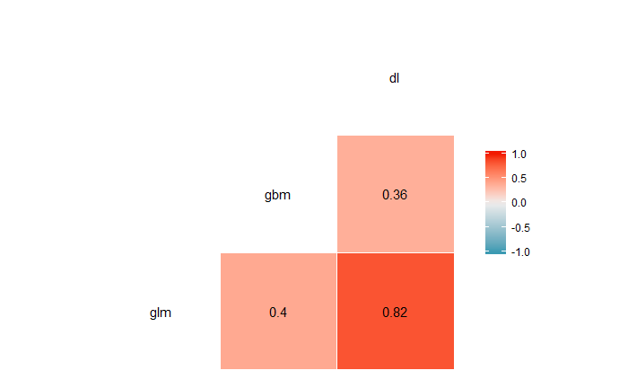

# performance metric is AUC!!

```r
print(h2o.auc(h2o.performance(deeplearning_model, newdata = data_test)))
```

```
[1] 0.6786425
```

```r
# for the ensemble model
print(h2o.auc(h2o.performance(ensemble_model, newdata = data_test)))
```

```
[1] 0.7113475
```

The baseline meta-learner is a glm model. You can try others:

```r
ensemble_model_gbm <- h2o.stackedEnsemble(
  X, y,
  training_frame = data_train,
  metalearner_algorithm = "gbm",
  base_models = list(glm_model,
                     gbm_model,
                     deeplearning_model))
```

```r
print(h2o.auc(h2o.performance(ensemble_model_gbm, newdata = data_test)))
```

```
[1] 0.7108228
```

Meta-learning can also be built upon same-family, different hyperparameter models via a grid of hyperparameters.

```r
gbm_grid <- h2o.grid(
  x = X, y = y,
  training_frame = data_train,
  algorithm = "gbm",
  ntrees = 10,
  hyper_params = hyper_params,
  seed = 123,
  nfolds = 5,
  keep_cross_validation_predictions = TRUE)
```

```r
ensemble_model_grid_gbm <- h2o.stackedEnsemble(
  X, y,
  training_frame = data_train,
  base_models = gbm_grid@model_ids)
```

```r
# individual test set performances
for (model_id in gbm_grid@model_ids) {
  model <- h2o.getModel(model_id)
  print(model_id)
  print(h2o.auc(h2o.performance(model, newdata = data_test)))
}
```

```
[1] "Grid_GBM_RTMP_sid_9b88_3_model_R_1582730620731_1161_model_2"
[1] 0.6908307
[1] "Grid_GBM_RTMP_sid_9b88_3_model_R_1582730620731_1161_model_1"
[1] 0.6952421
[1] "Grid_GBM_RTMP_sid_9b88_3_model_R_1582730620731_1161_model_3"
[1] 0.6867792
[1] "Grid_GBM_RTMP_sid_9b88_3_model_R_1582730620731_1161_model_5"
[1] 0.6747192
[1] "Grid_GBM_RTMP_sid_9b88_3_model_R_1582730620731_1161_model_4"
[1] 0.6808954
[1] "Grid_GBM_RTMP_sid_9b88_3_model_R_1582730620731_1161_model_6"
[1] 0.6642316
```

```r
print(h2o.auc(h2o.performance(ensemble_model_grid_gbm, newdata = data_test)))
```

```
[1] 0.6994005
```

## AutoML

Based on stacking H2O offers an out-of-the-box tool called “auto ML”. It runs some models that differ from each other and then creates a stacked version of them. Finally, the best model is selectd.

```r
automl_model <- h2o.automl(X, y,
  training_frame = data_train,
  max_runtime_secs = 120)  # you can specify how long (approx.) you want the estimation to run
```

```
17:00:52.761: AutoML: XGBoost is not available; skipping it.
```

[output not shown]

[output cut: 10 more lines]

```r
print(lb, n = nrow(lb))
```

```
[20 rows x 7 columns]
```

```r
# the best performing model is stored in '@leader'
automl_model@leader
```

```
Model Details:
==============

H2OBinomialModel: stackedensemble
Model ID:  StackedEnsemble_AllModels_AutoML_20200226_170052
NULL


H2OBinomialMetrics: stackedensemble
** Reported on training data. **

MSE:  0.07902082
RMSE:  0.2811064
LogLoss:  0.2836584
Mean Per-Class Error:  0.1135959
AUC:  0.9705874
AUCPR:  0.8937594
Gini:  0.9411748

Confusion Matrix (vertical: actual; across: predicted) for F1-optimal threshold:
```

|  | N | Y | Error | Rate |
| --- | --- | --- | --- | --- |
| N | 15306 | 923 | 0.056873 | =923/16229 |
| Y | 653 | 3181 | 0.170318 | =653/3834 |
| Totals | 15959 | 4104 | 0.078553 | =1576/20063 |

```
Maximum Metrics: Maximum metrics at their respective thresholds
```

|  | metric | threshold | value | idx |
| --- | --- | --- | --- | --- |
| 1 | max f1 | 0.301750 | 0.801461 | 211 |
| 2 | max f2 | 0.239165 | 0.856896 | 247 |
| 3 | max f0point5 | 0.399863 | 0.829035 | 165 |
| 4 | max accuracy | 0.333215 | 0.923740 | 196 |
| 5 | max precision | 0.935614 | 1.000000 | 0 |
| 6 | max recall | 0.131309 | 1.000000 | 326 |
| 7 | max specificity | 0.935614 | 1.000000 | 0 |
| 8 | max absolute_mcc | 0.301750 | 0.753247 | 211 |
| 9 | max min_per_class_accuracy | 0.260398 | 0.904862 | 234 |
| 10 | max mean_per_class_accuracy | 0.243639 | 0.906410 | 244 |

[output cut: 8 more lines]

```
Gains/Lift Table: Extract with `h2o.gainsLift(<model>, <data>)` or `h2o.gainsLift(<model>, valid=<T/F>, xval=<T/F>)`

H2OBinomialMetrics: stackedensemble
** Reported on cross-validation data. **
** 5-fold cross-validation on training data (Metrics computed for combined holdout predictions) **

MSE:  0.1400885
RMSE:  0.374284
LogLoss:  0.4431163
Mean Per-Class Error:  0.3502177
AUC:  0.7145538
AUCPR:  0.3764696
Gini:  0.4291076

Confusion Matrix (vertical: actual; across: predicted) for F1-optimal threshold:
```

|  | N | Y | Error | Rate |
| --- | --- | --- | --- | --- |
| N | 11956 | 4273 | 0.263294 | =4273/16229 |
| Y | 1676 | 2158 | 0.437141 | =1676/3834 |
| Totals | 13632 | 6431 | 0.296516 | =5949/20063 |

```
Maximum Metrics: Maximum metrics at their respective thresholds
```

|  | metric | threshold | value | idx |
| --- | --- | --- | --- | --- |
| 1 | max f1 | 0.204907 | 0.420458 | 248 |
| 2 | max f2 | 0.114399 | 0.584513 | 338 |
| 3 | max f0point5 | 0.303280 | 0.395646 | 174 |
| 4 | max accuracy | 0.567867 | 0.813587 | 59 |
| 5 | max precision | 0.760868 | 0.758621 | 9 |
| 6 | max recall | 0.065892 | 1.000000 | 398 |
| 7 | max specificity | 0.874544 | 0.999938 | 0 |
| 8 | max absolute_mcc | 0.274712 | 0.252654 | 192 |
| 9 | max min_per_class_accuracy | 0.176238 | 0.649713 | 274 |
| 10 | max mean_per_class_accuracy | 0.144006 | 0.652884 | 306 |

[output cut: 8 more lines]

```
Gains/Lift Table: Extract with `h2o.gainsLift(<model>, <data>)` or `h2o.gainsLift(<model>, valid=<T/F>, xval=<T/F>)`
```

```r
print(h2o.auc(h2o.performance(automl_model@leader, newdata = data_test)))
```

```
[1] 0.7184903
```

For a more in-depth tutorial, see [here](https://github.com/h2oai/h2o-tutorials/tree/master/h2o-world-2017/automl).